# Homework 4

Arlette Hall

2026-01-20

## Instructions

Answer the following questions and/or complete the exercises in RMarkdown. Please embed all of your code and push the final work to your repository. Your report should be organized, clean, and run free from errors. Remember, you must remove the `#` for any included code chunks to run. Any plots must have appropriate titles and aesthetics.

## Load the tidyverse

```r
library("tidyverse")
options(scipen = 999) #disable scientific notation
```

For this homework, we will be using the `msleep` dataset from the `ggplot2` package. This dataset contains information about the sleep habits of various mammals. [Reference](https://ggplot2.tidyverse.org/reference/msleep.html): V. M. Savage and G. B. West. A quantitative, theoretical framework for understanding mammalian sleep. Proceedings of the National Academy of Sciences, 104 (3):1051-1056, 2007.

**1. Use a summary function of your choice to get an idea of the structure of the msleep data.**

```r
str(msleep) #check dimensions, col names, data types in msleep dataset
```

```
## tibble [83 × 11] (S3: tbl_df/tbl/data.frame)
##  $ name        : chr [1:83] "Cheetah" "Owl monkey" "Mountain beaver" "Greater short-tailed shrew" ...
##  $ genus       : chr [1:83] "Acinonyx" "Aotus" "Aplodontia" "Blarina" ...
##  $ vore        : chr [1:83] "carni" "omni" "herbi" "omni" ...
##  $ order       : chr [1:83] "Carnivora" "Primates" "Rodentia" "Soricomorpha" ...
##  $ conservation: chr [1:83] "lc" NA "nt" "lc" ...
##  $ sleep_total : num [1:83] 12.1 17 14.4 14.9 4 14.4 8.7 7 10.1 3 ...
##  $ sleep_rem   : num [1:83] NA 1.8 2.4 2.3 0.7 2.2 1.4 NA 2.9 NA ...
##  $ sleep_cycle : num [1:83] NA NA NA 0.133 0.667 ...
##  $ awake       : num [1:83] 11.9 7 9.6 9.1 20 9.6 15.3 17 13.9 21 ...
##  $ brainwt     : num [1:83] NA 0.0155 NA 0.00029 0.423 NA NA NA 0.07 0.0982 ...
##  $ bodywt      : num [1:83] 50 0.48 1.35 0.019 600 ...
```

**2. What are the names of the variables? To get a better idea of what the variables mean, you can use `?msleep`.**

```r
names(msleep) #view variable names in msleep dataset
```

```
##  [1] "name"         "genus"        "vore"         "order"        "conservation"
##  [6] "sleep_total"  "sleep_rem"    "sleep_cycle"  "awake"        "brainwt"
## [11] "bodywt"
```

**3. Make a plot that shows the number of mammals in each vore type. Which vore type is most represented in the data?**

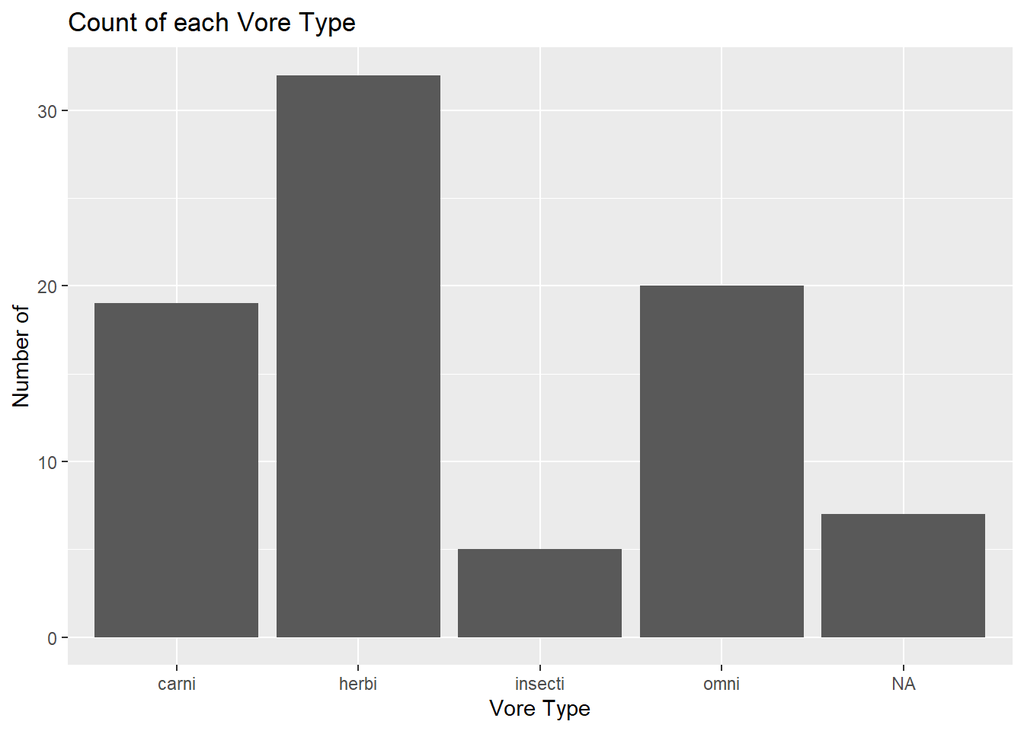

```r
ggplot(data=msleep,
       mapping=aes(x=vore))+
  geom_bar()+
  labs(x = "Vore Type", y = "Number of", title = "Count of each Vore Type")
```

```r
#herbi (herbivore) is most represented in the data
```

**4. What is the average length of time that each mammal sleeps?**

```r
avg_sleep <- mean(msleep$sleep_total)
avg_sleep
```

```
## [1] 10.43373
```

**5. Use `summary()` to get a quick idea of the range of values for the variable `bodywt`.**

```r
summary(msleep$bodywt)
```

```
##     Min.  1st Qu.   Median     Mean  3rd Qu.     Max.
##    0.005    0.174    1.670  166.136   41.750 6654.000
```

**6. Build a plot that shows the range of `bodywt.` by vore type. Because the range of `bodywt` is so variable, you will need to scale the y-axis. You do this by adding `scale_y_log10()` as another layer.**

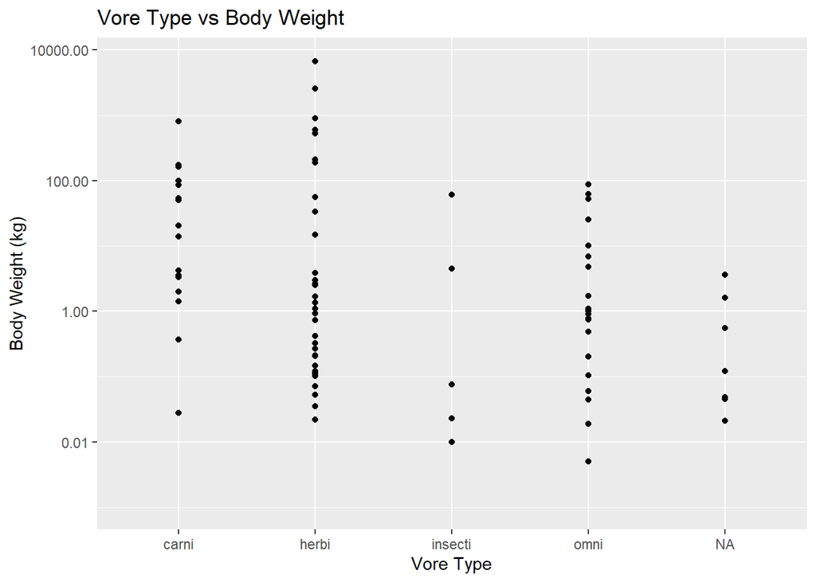

```r
ggplot(data=msleep,
       mapping=aes(x=vore, y=bodywt))+
  geom_point(na.rm=T)+
  labs(x = "Vore Type", y = "Body Weight (kg)", title = "Vore Type vs Body Weight")+
  scale_y_log10(
    limits = c(0.001, 7000)
  )
```

**7. Is there a relationship between body weight and total sleep time? Add appropriate labels and a title to your plot.**

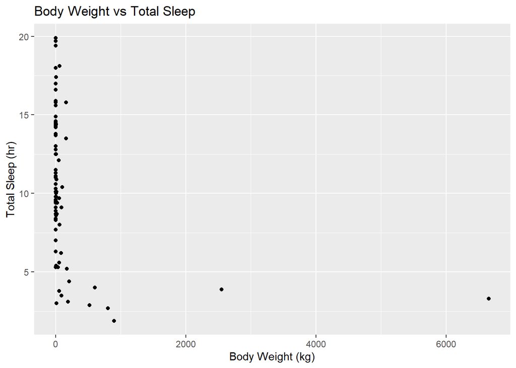

```r
ggplot(data=msleep,
       mapping=aes(x=bodywt, y=sleep_total))+
  geom_point(na.rm=T)+
  labs(x = "Body Weight (kg)", y = "Total Sleep (hr)", title = "Body Weight vs Total Sleep")
```